# Bundel, Berkas, dan Kohomologi - Unit 1-30

### Soal 28.10

Tinjau garis projektif $\mathbb P^1_K$ dan sistem linear lengkap

$$L:=\langle s,t\rangle
=\Gamma(\mathbb P^1_K,\mathcal O_{\mathbb P^1_K}(1)).$$

Buktikan bahwa pemilihan suatu sistem pembangkit $L$ yang terdiri atas tiga unsur, hingga perkalian skalar, bersesuaian dengan embedding garis projektif ke bidang projektif sebagai sebuah garis. Bagaimana garis citra itu dapat dijelaskan?

### Soal 28.11

Tinjau garis projektif $\mathbb P^1_K$ dan sistem linear lengkap

$$L:=\langle s^2,st,t^2\rangle
=\Gamma(\mathbb P^1_K,\mathcal O_{\mathbb P^1_K}(2)).$$

Buktikan bahwa pemilihan suatu basis $L$, hingga perkalian skalar, bersesuaian dengan embedding garis projektif ke bidang projektif. Bagaimana kurva citranya dapat dijelaskan?

### Soal 28.12

Tinjau garis projektif $\mathbb P^1_K$ dan sistem linear lengkap

$$L:=\langle s^3,s^2t,st^2,t^3\rangle
=\Gamma(\mathbb P^1_K,\mathcal O_{\mathbb P^1_K}(3)).$$

Buktikan bahwa pemetaan yang terkait

$$\mathbb P^1_K\longrightarrow\mathbb P^3_K$$

memberikan embedding garis projektif ke ruang projektif. Berikan sebanyak mungkin persamaan yang dipenuhi kurva citra.

> **Catatan edisi (sumber).** Judul halaman soal yang ditransklusikan memuat segmen `O(4)`, tetapi pernyataan soal sendiri memakai empat seksi kubik dan $\mathcal O(3)$. Edisi ini mempertahankan rumus yang tampil pada soal; judul sumber persisnya tetap dicatat dalam penanda entitas di atas.

### Soal 28.13

Misalkan $X$ skema di atas gelanggang komutatif $R$, $\mathcal L$ berkas invertibel pada $X$, dan $s_0,s_1,\ldots,s_n\in\Gamma(X,\mathcal L)$ seksi global. Misalkan $L\to X$ adalah bundel garis dalam pengertian Teorema 17.10 untuk berkas invertibel dual $\mathcal L^*$, sehingga $s_i$ dapat dipandang sebagai morfisme

$$L\longrightarrow X\times\mathbb A^1_R\longrightarrow\mathbb A^1_R.$$

Buktikan bahwa terdapat diagram komutatif

$$\begin{array}{rclcrcl}
& L & & \xrightarrow{(s_0,s_1,\ldots,s_n)} & & \mathbb A^{n+1}_R\supseteq\displaystyle\bigcup_{i=0}^{n}D(x_i) & \\
& \downarrow & & & & \downarrow & {\scriptstyle \pi}\\
& X\supseteq\displaystyle\bigcup_{i=0}^{n}X_{s_i} & & \xrightarrow{\varphi_{s_0,s_1,\ldots,s_n,\mathcal L}} & & \mathbb P^n_R, &
\end{array}$$

dengan pemetaan kerucut pada sisi kanan.

> **Catatan edisi (sumber).** Pada kedua gabungan di diagram sumber, indeks tercetak mulai dari $i=1$, walaupun keluarga seksinya adalah $s_0,\ldots,s_n$ dan pemetaan kerucut memakai semua koordinat. Edisi ini menampilkan batas $i=0,\ldots,n$ yang konsisten dengan pernyataan.

### Soal 28.14

Misalkan $X$ skema di atas gelanggang komutatif $R$, $\mathcal L$ berkas invertibel pada $X$, dan $s_0,s_1,\ldots,s_n\in\Gamma(X,\mathcal L)$ seksi global. Buktikan bahwa pernyataan berikut ekuivalen.

1. $X=\bigcup_{i=0}^{n}X_{s_i}$.
2. Morfisme ke $\mathbb P^n_R$ yang diberikan oleh sistem linear $(s_0,s_1,\ldots,s_n)$ terdefinisi pada seluruh $X$.
3. Sistem linear $(s_0,s_1,\ldots,s_n)$ bebas titik basis.

# Solusi Publik dan Cakupan Lembar Kerja 28

Untuk masing-masing dari 14 judul halaman soal resmi, halaman calon literal `<soal>/Lösung` diperiksa secara langsung. Pemeriksaan ini menemukan tepat satu halaman solusi publik, yaitu solusi Soal 28.6. Ketiga belas calon lainnya beralih ke tampilan pembuatan halaman resmi yang menyatakan bahwa halaman tersebut belum ada. Ketiadaan tautan yang tampak pada halaman lembar kerja tidak digunakan sebagai bukti negatif.

## Solusi Soal 28.6

Karena $v_1,v_2$ dan $w_1,w_2$ merupakan basis, menurut teorema penentuan terdapat sebuah pemetaan linear bijektif

$$\psi:V\longrightarrow V$$

dengan

$$\phi(v_1)=w_1
\qquad\text{dan}\qquad
\phi(v_2)=w_2.$$

Di bawah $\psi$, asumsi bahwa setiap pasangan bebas linear tetap berlaku.

Oleh karena itu, kita hanya perlu meninjau situasi dua keluarga vektor yang berbentuk $v_1,v_2,y$ dan $v_1,v_2,z$. Misalkan

$$y=av_1+bv_2$$

dan

$$z=cv_1+dv_2.$$

Di sini

$$a,b,c,d\ne 0,$$

sebab jika tidak demikian, $y$, masing-masing $z$, akan bergantung linear dengan salah satu $v_i$. Sekarang kita meninjau pemetaan linear $\phi$ yang diberikan oleh

$$v_1\longmapsto \frac ca v_1
\qquad\text{dan}\qquad
v_2\longmapsto \frac db v_2.$$

Maka

$$\begin{aligned}
\phi(y)
&=\phi(av_1+bv_2)\\
&=a\phi(v_1)+b\phi(v_2)\\
&=a\frac ca v_1+b\frac db v_2\\
&=cv_1+bv_2\\
&=z.
\end{aligned}$$

Dengan demikian, $\phi$ memenuhi syarat yang diminta.

> **Catatan edisi (sumber).** Solusi sumber memperkenalkan pemetaan $\psi$ tetapi menuliskan nilai-nilai basis dan pemetaan lanjutan dengan lambang $\phi$ tanpa menjelaskan komposisinya. Pada baris terakhir sumber juga tertulis $cv_1+bv_2=z$, padahal sebelumnya $z=cv_1+dv_2$; agar kesamaan itu benar, koefisien kedua harus $d$. Edisi ini mempertahankan dua ketidaktepatan tersebut di badan solusi dan mengungkapkannya di sini.

## Hasil negatif yang dibuktikan calon langsung

Halaman calon literal `<soal>/Lösung` saat ini tidak ada untuk Soal 28.1, 28.2, 28.3, 28.4, 28.5, 28.7, 28.8, 28.9, 28.10, 28.11, 28.12, 28.13, dan 28.14. Setiap URL calon tersebut beralih ke tampilan pembuatan halaman resmi yang menyatakan, “Diese Seite existiert noch nicht” (“Halaman ini belum ada”). Pernyataan ini mencatat cakupan halaman sumber, bukan klaim bahwa solusi matematis tidak ada.

# Kredit media BGK Unit 28

Sumber kursus: **Kurs:Bündel, Garben und Kohomologie (Osnabrück 2019-2020)**, Kurs:Bündel, Garben und Kohomologie (Osnabrück 2019-2020)/Vorlesung 28 dan Kurs:Bündel, Garben und Kohomologie (Osnabrück 2019-2020)/Arbeitsblatt 28.

Unit ini tidak memiliki posisi media substantif untuk pembaca, sehingga tidak ada keterangan gambar atau teks alternatif komponen yang perlu ditambahkan. Dua berkas PDF resmi yang muncul pada permukaan parse dibekukan hanya sebagai saksi authority; identitas, atribusi, lisensi, revisi, ukuran, dan hash keduanya tercatat dalam penutupan aset, bukan sebagai media pembaca.

# Kuliah 29: Genus Kurva

## Kurva projektif mulus dan genusnya

### Definisi 29.1: genus

Untuk suatu kurva projektif mulus $C$ di atas lapangan tertutup aljabar $K$, bilangan

$$g:=\dim_K H^1(C,\mathcal O_C)$$

disebut *genus* kurva tersebut.

Menurut Teorema 27.7, dimensi $H^1(C,\mathcal O_C)$ berhingga. Jadi genus suatu kurva merupakan bilangan asli.

> **Ilustrasi sumber.** Tiga permukaan berikut memperlihatkan genus satu, dua, dan tiga melalui banyaknya pegangan. Ketiganya muncul dalam urutan ini pada kuliah resmi dan mempertahankan status domain publik komponennya.

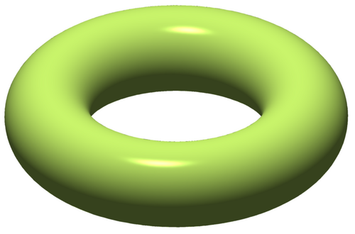

Permukaan torus berwarna hijau dengan satu pegangan, yaitu permukaan bergenus satu

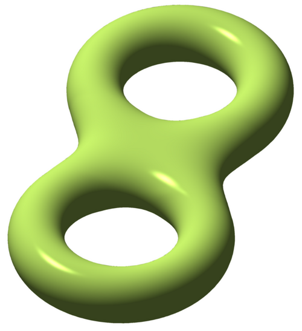

Permukaan torus ganda berwarna hijau dengan dua pegangan, yaitu permukaan bergenus dua

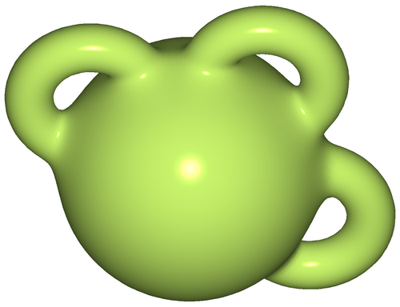

Permukaan hijau menyerupai bola dengan tiga pegangan, yaitu permukaan bergenus tiga

### Contoh 29.2

Menurut Teorema 27.4, genus garis projektif

$$\mathbb P^1_K=\operatorname{Proj}(K[X,Y])$$

adalah $0$.

### Definisi 29.3: kurva eliptik

Kurva projektif mulus $C$ ber-genus $1$ di atas lapangan tertutup aljabar $K$ disebut *kurva eliptik*.

### Catatan 29.4

Jika bilangan kompleks $\mathbb C$ dipilih sebagai lapangan dasar, genus kurva projektif mulus mempunyai interpretasi topologis sederhana. Kurva tersebut dapat dipandang sebagai manifold kompleks kompak berdimensi satu — suatu permukaan Riemann — dan juga sebagai manifold real kompak berorientasi berdimensi dua. Manifold jenis terakhir ini mempunyai klasifikasi topologis sederhana: setiap manifold demikian homeomorfik dengan permukaan bola yang diberi $g$ pegangan. Bilangan ini disebut genus topologis permukaan real, dan karena itu juga genus kurva.

Dapat dibuktikan bahwa genus yang didefinisikan secara aljabar melalui kohomologi pertama berkas struktur sama dengan genus topologis tersebut. Garis projektif kompleks merupakan bola berdimensi dua tanpa pegangan, jadi genus topologisnya $0$. Permukaan ber-genus $1$ adalah torus — seperti ban — yang homeomorfik dengan $S^1\times S^1$. Kurva projektif ber-genus $1$, yakni kurva eliptik, mempunyai bentuk topologis ini.

### Teorema 29.5

Misalkan

$$C=V_+(f)\subseteq\mathbb P^2_K$$

kurva bidang projektif berderajat $d$ di atas lapangan tertutup aljabar $K$. Maka

$$\dim_K H^1(C,\mathcal O_C)=\frac{(d-1)(d-2)}{2}.$$

#### Bukti

Tinjau barisan eksak pendek (bandingkan Soal 13.23)

$$0\longrightarrow\mathcal O_{\mathbb P^2_K}(-d)
\xrightarrow{\ f\ }
\mathcal O_{\mathbb P^2_K}
\longrightarrow\mathcal O_C\longrightarrow0$$

berkas koheren pada bidang projektif. Berkas struktur $\mathcal O_C$ di sini dipandang sebagai berkas pada bidang projektif dengan dukungan $C$. Potongan barisan eksak panjang kohomologi yang terkait adalah

$$H^1(\mathbb P^2_K,\mathcal O_{\mathbb P^2_K})=0
\longrightarrow H^1(\mathbb P^2_K,\mathcal O_C)
\longrightarrow H^2(\mathbb P^2_K,\mathcal O_{\mathbb P^2_K}(-d))
\longrightarrow H^2(\mathbb P^2_K,\mathcal O_{\mathbb P^2_K})=0.$$

Kedua kesamaan nol mengikuti dari Teorema 27.4. Menurut teorema yang sama, ruang

$$H^2(\mathbb P^2_K,\mathcal O_{\mathbb P^2_K}(-d))$$

mempunyai basis yang terdiri atas semua monomial $x^iy^jz^k$ dengan semua eksponen negatif dan $i+j+k=-d$. Jadi kita harus menghitung tupel $(\alpha,\beta,\gamma)$ berderajat $d-3$. Menurut Soal 12.4, banyaknya adalah

$$\binom{d-3+2}{2}=\binom{d-1}{2}=\frac{(d-1)(d-2)}{2}.$$

Menurut Teorema 27.6, $H^1(\mathbb P^2_K,\mathcal O_C)=H^1(C,\mathcal O_C)$, yang membuktikan pernyataan. $\square$

> **Catatan edisi (saksi PDF).** Saksi PDF resmi 2020 masih merujuk Soal 11.4; revisi semantik beku yang menjadi kanon edisi ini telah memperbarui rujukan tersebut menjadi Soal 12.4.

Dalam kasus mulus, teorema ini memberikan rumus untuk menghitung genus kurva bidang:

| $d$ | 1 | 2 | 3 | 4 | 5 |
| --- | --- | --- | --- | --- | --- |
| $g$ | 0 | 0 | 1 | 3 | 6 |

Untuk $d=1$ kita memperoleh garis projektif ber-genus $0$. Untuk $d=2$ kita memperoleh kuadrik projektif bidang — suatu irisan kerucut — yang juga ber-genus $0$ dan memang isomorfik dengan garis projektif. Untuk $d=3$ genus adalah $1$, sehingga kurvanya eliptik. Dapat dibuktikan bahwa setiap kurva eliptik dapat direalisasikan sebagai kurva kubik bidang. Sama sekali tidak jelas sebelumnya bahwa ada kurva projektif mulus untuk setiap genus. Menurut Teorema 29.5, tidak semuanya dapat direalisasikan sebagai kurva bidang.

### Catatan 29.6

Genus kurva projektif mulus yang didefinisikan secara kohomologis sama dengan dimensi ruang vektor berkas kanoniknya. Dalam dimensi satu, berkas kanonik adalah berkas diferensial Kähler $\Omega_{C\mid K}$, yakni berkas kotangen dan dual berkas tangen. Jadi

$$\dim_K H^1(C,\mathcal O_C)
=\dim_K\Gamma(C,\omega_C).$$

Untuk kurva bidang hal ini terlihat langsung. Menurut Teorema 29.5, genusnya adalah $(d-1)(d-2)/2$. Korolari 19.12 memberikan $\omega_C\cong\mathcal O_C(d-3)$, dan menurut Soal 27.10 dimensi $\Gamma(C,\mathcal O_C(d-3))$ juga sama dengan $(d-1)(d-2)/2$.

Dalam kasus umum berlaku dualitas Serre. Salah satu isinya ialah: untuk berkas bebas lokal $\mathcal F$ pada kurva projektif mulus $C$, grup kohomologi $H^1(C,\omega_C)$ merupakan ruang vektor berdimensi satu di atas $K$, dan pemetaan alami

$$\operatorname{Hom}(\mathcal F,\omega_C)
\times H^1(C,\mathcal F)
\longrightarrow H^1(C,\omega_C)\cong K$$

memberikan dualitas sempurna. Dengan kata lain, $\operatorname{Hom}(\mathcal F,\omega_C)$ dan $H^1(C,\mathcal F)$ saling dual dan khususnya berdimensi sama. Untuk berkas struktur $\mathcal F=\mathcal O_C$, kesamaan $\operatorname{Hom}(\mathcal O_C,\omega_C)=\Gamma(C,\omega_C)$ dari Teorema 13.10 memberikan dualitas antara $H^1(C,\mathcal O_C)$ dan $\Gamma(C,\omega_C)$.

## Divisor pada kurva

Pada kurva projektif mulus $C$, seperti pada setiap skema normal berdimensi satu, divisor Weil hanyalah jumlah formal

$$\sum_{P\in C} n_P\,P$$

atas titik-titik tertutup $P$. Dalam kasus ini, titik-titik tersebut adalah divisor prima, yaitu subhimpunan tertutup tak tereduksi berkodimensi $1$. Koefisien $n_P\in\mathbb Z$ dan hanya berhingga banyak yang tidak nol. Menurut Korolari 22.11, grup kelas divisor sama dengan grup Picard.

Kita akan membahas perilaku divisor pada kurva di bawah morfisme. Morfisme antara dua kurva tak tereduksi selalu konstan atau mempunyai citra rapat. Morfisme tak konstan $\varphi:C_1\to C_2$ menginduksi perluasan lapangan fungsi

$$Q(C_2)\subseteq Q(C_1).$$

Mula-mula kita tunjukkan bahwa unsur lapangan fungsi suatu kurva mulus dapat dipandang sebagai morfisme ke garis projektif. Secara umum, untuk unsur tak konstan $q$ dalam lapangan fungsi skema normal $X$, divisor utama $\operatorname{div}(q)$ dapat diuraikan menjadi divisor nol dan divisor kutub dengan koefisien positif. Kedua divisor efektif itu ekuivalen linear dan, dalam kasus faktorial lokal menurut Soal 22.15, bersesuaian dengan seksi dalam berkas invertibel terkait $\mathcal O_X(\text{divisor nol}(q))$. Hasil kuliah sebelumnya menunjukkan bahwa kedua seksi ini menentukan morfisme ke garis projektif pada suatu himpunan terbuka $U\subseteq X$. Hasil berikut lebih kuat untuk kurva mulus: daerah definisinya adalah seluruh kurva.

> **Catatan edisi (saksi PDF).** Saksi PDF resmi 2020 masih merujuk Soal 22.13; revisi semantik beku yang menjadi kanon edisi ini telah memperbarui rujukan tersebut menjadi Soal 22.15.

### Lema 29.7

Misalkan $C$ kurva mulus tak tereduksi di atas lapangan tertutup aljabar $K$ dan $Q$ lapangan fungsinya. Setiap fungsi rasional $q\in Q$ secara alami menentukan morfisme

$$q:C\longrightarrow\mathbb P^1_K.$$

#### Bukti

Misalkan

$$U:=\{P\in C\mid q\in\mathcal O_{C,P}\}$$

daerah definisi $q$ sebagai fungsi ke garis afin, dan, jika $q\ne0$,

$$V:=\{P\in C\mid q^{-1}\in\mathcal O_{C,P}\}.$$

Kita mempunyai $C=U\cup V$, sebab setiap $\mathcal O_{C,P}$ merupakan gelanggang valuasi diskret dan di sana $q=\pi^n u$ untuk suatu unit $u\in\mathcal O_{C,P}$, parameter lokal $\pi\in\mathcal O_{C,P}$, dan $n\in\mathbb Z$. Menurut Korolari 10.12 terdapat morfisme

$$q:U\longrightarrow\mathbb A^1_K
=\operatorname{Spec}K\!\left[\frac YX\right]
\cong D_+(X)\subseteq\mathbb P^1_K$$

dan morfisme

$$q^{-1}:V\longrightarrow\mathbb A^1_K
=\operatorname{Spec}K\!\left[\frac XY\right]
\cong D_+(Y)\subseteq\mathbb P^1_K.$$

Keduanya bersesuaian dengan homomorfisme substitusi $Y/X\mapsto q$ dan $X/Y\mapsto q^{-1}$. Pada $U\cap V$ kedua morfisme berimpit, sehingga mereka merekat menjadi morfisme ke garis projektif. $\square$

### Definisi 29.8: indeks ramifikasi

Untuk homomorfisme gelanggang injektif $R\subseteq S$ antara gelanggang valuasi diskret, orde suatu penyeragam lokal $R$ di dalam $S$ disebut *indeks ramifikasi* perluasan tersebut.

Orde ramifikasi dilambangkan $\operatorname{Ram}(S\mid R)$. Jika $\varphi:C_1\to C_2$ morfisme tak konstan antara kurva mulus di atas lapangan tertutup aljabar, maka untuk setiap titik tertutup $Q\in C_1$ dengan titik citra $\varphi(Q)\in C_2$ terdapat perluasan gelanggang valuasi diskret

$$\mathcal O_{C_2,\varphi(Q)}\subseteq\mathcal O_{C_1,Q}.$$

Orde ramifikasi terkait juga disebut orde ramifikasi $\varphi$ di $Q$ dan dilambangkan $\operatorname{Ram}(Q\mid\varphi(Q))$.

> **Catatan edisi (sumber dan saksi PDF).** Revisi semantik beku memakai *Verzweigungsindex* (“indeks ramifikasi”) di dalam definisi, lalu *Verzweigungsordnung* (“orde ramifikasi”) dalam paragraf berikutnya. Saksi PDF resmi 2020 memakai *Verzweigungsordnung* juga di dalam definisi. Edisi ini mempertahankan perbedaan istilah antarsaksi tersebut secara eksplisit.

### Definisi 29.9: tarik balik divisor Weil

Misalkan $\varphi:C_1\to C_2$ morfisme tak konstan antara kurva mulus di atas lapangan tertutup aljabar dan

$$D=\sum_P a_P\,P$$

divisor Weil pada $C_2$. Divisor Weil

$$\varphi^*D
:=\sum_{Q\in C_1}
\operatorname{Ram}(Q\mid\varphi(Q))a_{\varphi(Q)}\,Q$$

disebut *divisor Weil tarik balik*.

Untuk satu titik $P\in C_2$, divisor tarik baliknya adalah

$$\sum_{Q\in\varphi^{-1}(P)}
\operatorname{Ram}(Q\mid P)\,Q.$$

Jadi ini pada dasarnya adalah serat di atas $P$, tetapi titik ramifikasi — titik dengan orde ramifikasi sedikitnya $2$ — dihitung berulang sesuai ordenya.

### Lema 29.10

Misalkan $\varphi:C_1\to C_2$ morfisme tak konstan antara kurva mulus tak tereduksi di atas lapangan tertutup aljabar, dan misalkan

$$D=\sum_P a_P\,P=\operatorname{div}(q)$$

divisor utama pada $C_2$, dengan $q\in Q(C_2)$ dan $q\ne0$. Maka $\varphi^*(D)$ sama dengan divisor utama $q\in Q(C_1)$ pada $C_1$.

#### Bukti

Karena $\varphi$ tak konstan, terdapat perluasan lapangan $Q(C_2)\subseteq Q(C_1)$. Untuk setiap $Q\in C_1$ terdapat diagram komutatif homomorfisme injektif

$$\begin{array}{rclcrcl}
& \mathcal O_{C_2,\varphi(Q)} & & \xrightarrow{} & & \mathcal O_{C_1,Q} & \\
& \downarrow & & & & \downarrow & \\
& Q(C_2) & & \xrightarrow{} & & Q(C_1), &
\end{array}$$

dengan gelanggang valuasi diskret pada baris pertama. Jika $q=u\pi_2^n$, dengan $u\in\mathcal O_{C_2,\varphi(Q)}$ suatu unit dan $\pi_2$ penyeragam lokal, maka sumber menuliskan

$$q=u\pi_2^n
=u\bigl(u'\pi_1^{\operatorname{Ram}(Q\mid\varphi(Q))}\bigr)^n
=uu'\pi_1^{n\operatorname{Ram}(Q\mid\varphi(Q))},$$

dengan $\pi_1$ penyeragam lokal $\mathcal O_{C_1,Q}$. Ini memberikan pernyataan. $\square$

> **Catatan edisi (sumber dan saksi PDF).** Revisi semantik beku memakai urutan $\operatorname{Ram}(Q\mid\varphi(Q))$ di atas, sedangkan saksi PDF resmi 2020 membalik argumennya menjadi $\operatorname{Ram}(\varphi(Q)\mid Q)$. Edisi ini mengikuti revisi semantik beku. Namun, ketika $(u'\pi_1^e)^n$ dikembangkan, kedua saksi menulis faktor unit $u'$ alih-alih $(u')^n$; tampilan sumber itu dipertahankan dan ketidaktepatannya diungkapkan di sini.

### Korolari 29.11

Misalkan $C$ kurva mulus tak tereduksi di atas lapangan tertutup aljabar $K$, $Q$ lapangan fungsinya, dan $q\in Q\setminus K$. Untuk morfisme terkait

$$q:C\longrightarrow\mathbb P^1_K$$

berlaku

$$q^*((0)-(\infty))=\operatorname{div}(q).$$

#### Bukti

Lapangan fungsi garis projektif $\mathbb P^1_K=\operatorname{Proj}(K[X,Y])$ adalah $K(t)$ dengan $t=Y/X$. Perluasan lapangan fungsi diberikan oleh

$$K(t)\longrightarrow Q(C),\qquad t\longmapsto q.$$

Divisor utama $t$ adalah $(0)-(\infty)=(Y)-(X)$. Jadi pernyataan mengikuti dari Lema 29.10. $\square$

## Derajat divisor

### Definisi 29.12

Misalkan $C$ kurva projektif mulus di atas lapangan tertutup aljabar $K$. Derajat divisor Weil $D=\sum_{P\in C}n_P P$ didefinisikan sebagai

$$\deg(D):=\sum_{P\in C}n_P.$$

### Teorema 29.13

Misalkan $C$ kurva projektif mulus di atas lapangan tertutup aljabar $K$. Derajat setiap divisor utama sama dengan $0$.

Teorema ini diberikan tanpa bukti. Akibatnya, homomorfisme grup

$$\operatorname{Div}(C)\longrightarrow\mathbb Z,
\qquad D\longmapsto\deg(D),$$

memfaktor melalui grup kelas divisor $C$. Karena itu definisi berikut masuk akal.

### Definisi 29.14

Misalkan $C$ kurva projektif mulus di atas lapangan tertutup aljabar $K$. Derajat berkas invertibel $\mathcal L$ pada $C$ didefinisikan sebagai derajat suatu divisor Weil yang bersesuaian dengannya.

“Bersesuaian” berarti bahwa divisor $D$ dikaitkan dengan berkas invertibel $\mathcal O_C(D)$; khususnya, divisor efektif bersesuaian dengan seksi-seksi dalam berkas tersebut.

# Lembar Kerja 29: Genus Kurva

### Soal 29.1

Buktikan bahwa data atau konstruksi berikut menentukan morfisme yang sama $\mathbb P^1_K\to\mathbb P^1_K$, dengan $(a,b),(c,d)\in K^2$ bebas linear.

1. Morfisme yang diinduksi menurut Teorema 12.11 oleh homomorfisme gelanggang homogen $K[X,Y]\to K[S,T]$ dengan $X\mapsto aS+bT$ dan $Y\mapsto cS+dT$.
2. Morfisme menurut Lema 28.1 yang diberikan oleh dua seksi
   $$as+bt,\ cs+dt\in
   \Gamma(\mathbb P^1_K,\mathcal O_{\mathbb P^1_K}(1)).$$
3. Morfisme menurut Lema 29.7 yang diberikan oleh fungsi rasional
   $$\frac{as+bt}{cs+dt}\in K\!\left(\frac st\right).$$

### Soal 29.2

Buktikan bahwa terdapat morfisme

$$V(X^2-Y^3)\supseteq
U=V(X^2-Y^3)\setminus\{(0,0)\}
\longrightarrow\mathbb A^1$$

yang tidak dapat diperluas ke seluruh $V(X^2-Y^3)$.

### Soal 29.3

Misalkan $K$ lapangan, $C\subseteq\mathbb P^2_K$ kurva bidang projektif, $P\in C$, dan

$$\varphi:C\setminus\{P\}\longrightarrow\mathbb P^1_K$$

morfisme yang didefinisikan oleh proyeksi menjauhi $P$. Jadi titik $Q\in C$, $Q\ne P$, dipetakan ke garis sekan melalui $Q$ dan $P$.

1. Misalkan $K=\mathbb C$ dan $(Q_n)$ barisan pada $C$ yang konvergen ke $P$ dalam topologi kompleks. Apakah $\varphi(Q_n)$ konvergen?
2. Apakah $\varphi(Q_n)$ mempunyai titik akumulasi?
3. Misalkan $P$ titik mulus. Buktikan bahwa morfisme dapat diperluas ke seluruh $C$.

### Soal 29.4

Diskusikan situasi Soal 29.3 untuk persilangan sumbu

$$V_+(YZ)\subseteq\mathbb P^2$$

dan titik persilangannya $(1,0,0)$.

### Soal 29.5 ★

Misalkan $K$ lapangan tertutup aljabar berkarakteristik $0$, misalkan $C\subseteq\mathbb P^2_K$ kurva bidang projektif tak tereduksi berderajat $d$, dan misalkan

$$\varphi:C\longrightarrow\mathbb P^1_K$$

morfisme yang diberikan oleh proyeksi menjauhi titik $P\notin C$. Buktikan bahwa, dengan paling banyak berhingga banyak pengecualian, serat di atas setiap $t\in\mathbb P^1_K$ terdiri atas tepat $d$ titik.

### Soal 29.6

Misalkan $K$ lapangan tertutup aljabar dan $C\subseteq\mathbb P^2_K$ kurva mulus berderajat $d\ge2$. Buktikan bahwa terdapat morfisme $C\to\mathbb P^1_K$ sedemikian sehingga setiap serat terdiri atas paling banyak $d-1$ titik.

### Soal 29.7

Misalkan

$$C=V_+(X^3+Y^3+Z^3)\subseteq\mathbb P^2_K$$

kurva kubik Fermat di atas lapangan tertutup aljabar berkarakteristik bukan $3$. Jelaskan secara eksplisit suatu morfisme $C\to\mathbb P^1_K$ yang mempunyai paling banyak dua titik di atas setiap titik.

### Soal 29.8

Misalkan $C$ kurva projektif mulus tak tereduksi dengan lapangan fungsi $Q(C)$, dan $q\in Q(C)$ dengan morfisme terkait $q:C\to\mathbb P^1_K$. Misalkan $a\in K$. Buktikan bahwa terdapat automorfisme

$$\theta:\mathbb P^1_K\longrightarrow\mathbb P^1_K$$

sedemikian sehingga diagram

$$\begin{array}{rclcrcl}
& C & & \xrightarrow{q} & & \mathbb P^1_K & \\
{\scriptstyle q-a} & \downarrow & & & & \downarrow & {\scriptstyle \theta}\\
& \mathbb P^1_K & & = & & \mathbb P^1_K &
\end{array}$$

komutatif.

> **Catatan edisi (sumber).** Revisi semantik beku dan saksi PDF resmi 2020 menampilkan $Q(C)=$ dengan ruas kanan kosong. Edisi ini memperbaiki cacat tampak itu menjadi “dengan lapangan fungsi $Q(C)$” tanpa menambahkan asumsi matematis.

### Soal 29.9

Misalkan $C$ kurva projektif mulus tak tereduksi di atas lapangan tertutup aljabar dan $q\in Q(C)$ unsur tak konstan dengan morfisme terkait $q:C\to\mathbb P^1_K$. Buktikan bahwa untuk setiap $P\in\mathbb P^1_K$, divisor-divisor tarik balik $q^*(P)$ saling ekuivalen linear. Gunakan Soal 29.8.

### Soal 29.10

Misalkan $\mathbb P^1_K=\operatorname{Proj}(K[X,Y])$ dengan lapangan fungsi $K(t)$, $t=Y/X$. Jelaskan morfisme skema terkait

$$\mathbb P^1_K\longrightarrow\mathbb P^1_K,
\qquad t\longmapsto t^n,$$

untuk $n\in\mathbb N_+$. Apa pracitra titik nol? Apa pracitra titik di tak hingga? Bagaimana orde ramifikasinya?

### Soal 29.11

Misalkan $\mathbb P^1_K=\operatorname{Proj}(K[X,Y])$ dengan lapangan fungsi $K(t)$, $t=Y/X$, dan misalkan $P\in K[t]$ polinomial berderajat $e\ge1$. Jelaskan orde ramifikasi di $\infty$ untuk morfisme skema terkait

$$\mathbb P^1_K\longrightarrow\mathbb P^1_K,
\qquad t\longmapsto P.$$

### Soal 29.12 ★

Misalkan $\mathbb P^1_K=\operatorname{Proj}(K[X,Y])$ dan $\mathbb P^1_K=\operatorname{Proj}(K[W,Z])$ dua garis projektif dengan lapangan fungsi $K(t)$, $t=Y/X$, dan $K(u)$, $u=Z/W$, di atas lapangan tertutup aljabar $K$ berkarakteristik bukan $2$. Pada garis projektif kedua, tinjau sistem linear yang diberikan oleh

$$WZ,\ W^2+Z^2\in
\Gamma(\mathbb P^1_K,\mathcal O_{\mathbb P^1_K}(2))$$

dengan pemetaan terkait

$$\varphi:\mathbb P^1_K\longrightarrow\mathbb P^1_K,
\qquad (w,z)\longmapsto(wz,w^2+z^2).$$

1. Apakah sistem linear ini lengkap?
2. Tentukan pracitra $D_+(X)$ dan $D_+(Y)$ serta jelaskan pemetaan yang diinduksi antara bagian-bagian terbuka afin.
3. Apakah sistem linear ini bebas titik dasar?
4. Jelaskan perluasan lapangan fungsi $K(t)\subseteq K(u)$ yang terkait. Berapa derajatnya?
5. Untuk setiap $(x,y)\in\mathbb P^1_K$, tentukan pracitranya di bawah $\varphi$ serta orde ramifikasi masing-masing.
6. Jelaskan divisor tarik balik $\varphi^*(0-\infty)=\varphi^*((Y)-(X))$.

### Soal 29.13

Misalkan $X$ skema noetherian normal integral di atas lapangan $K$ dan $q\in Q(X)$. Buktikan bahwa $q$ mendefinisikan suatu morfisme

$$q:U\longrightarrow\mathbb P^1$$

pada suatu himpunan terbuka $U\subseteq X$, dengan kodimensi $X\setminus U$ sedikitnya $2$.

### Soal 29.14

Misalkan $\mathcal L$ berkas invertibel berderajat negatif pada kurva projektif mulus tak tereduksi $C$ di atas lapangan tertutup aljabar. Buktikan

$$\Gamma(C,\mathcal L)=0.$$

### Soal 29.15

Buktikan bahwa untuk kurva projektif mulus $C$ di atas lapangan tertutup aljabar, derajat berkas invertibel memberikan homomorfisme grup surjektif

$$\operatorname{Pic}(C)\longrightarrow\mathbb Z,
\qquad\mathcal L\longmapsto\deg(\mathcal L).$$

# Solusi Publik dan Cakupan Lembar Kerja 29

Pada revisi halaman resmi yang dibekukan, sumber menyediakan tepat dua solusi publik di antara 15 soal, yaitu solusi Soal 29.5 dan 29.12. Halaman ketiga belas soal lainnya hanya menawarkan pembuatan solusi baru. Ketiadaan halaman solusi publik tidak diubah menjadi solusi buatan.

## Solusi Soal 29.5

Kita meninjau sebuah garis $V_+(L)$ yang melalui titik $P$ beserta komplemen afinnya yang bersesuaian,

$$D_+(L)\cong \mathbb A_K^2.$$

Tanpa mengurangi keumuman, ambil

$$P=(1,0,0)$$

dan $L=Z$. Dengan demikian, kita dapat menganggap bahwa yang dibahas adalah proyeksi afin

$$\mathbb A_K^2\cong D_+(Z)
\longrightarrow
\mathbb A_K^1\cong D_+(Z),
\qquad
(x,y)\longmapsto y,$$

dan bahwa tersedia suatu kurva afin $V(F)$ berderajat $d$. Suku $X^d$ muncul dalam $F$, sebab jika tidak demikian maka $P\in C$. Kita memandang polinomial $F$ sebagai

$$F=G_dX^d+G_{d-1}X^{d-1}+\cdots+G_1X+G_0
\in K[Y][X]\subset K(Y)[X].$$

Di sini $G_i\in K[Y]$, sedangkan $G_d$ konstan. Karena kurva tersebut tak tereduksi, berlaku $G_0\ne 0$ apabila $d\geq 2$ (untuk $d=1$, keseluruhan pernyataan jelas dengan sendirinya). Kita harus menunjukkan bahwa, untuk semua kecuali berhingga banyak $y\in K$, polinomial

$$F(y)=G_d(y)X^d+G_{d-1}(y)X^{d-1}+\cdots+G_1(y)X+G_0(y)$$

mempunyai $d$ akar yang berbeda. Karena $F\in K(Y)[X]$ merupakan polinomial tak tereduksi dan kita berada dalam karakteristik $0$, polinomial $F$ separabel. Jadi $F$ dan $F'$ saling prima, dengan $F'$ menyatakan turunan formal terhadap $X$. Oleh karena itu, terdapat $S,T\in K(Y)$ sedemikian sehingga

$$SF+TF'=1.$$

Ini berarti bahwa terdapat polinomial $A,B,C\in K[Y]$ yang memenuhi

$$AF+BF'=C$$

dengan $C\ne 0$. Polinomial $C$ hanya mempunyai berhingga banyak akar. Untuk $y\in K$ dengan $C(y)\ne 0$, berlaku

$$A(y)F(y)+B(y)F(y)'=C(y),$$

yang berarti bahwa $F(y)$ dan $F(y)'=F'(y)$ saling prima di $K[X]$. Maka $F(y)$ dan turunannya $F(y)'$ tidak mempunyai akar bersama, sehingga tidak ada akar $F(y)$ yang berkelipatan.

## Solusi Soal 29.12

1. Sistem linear tersebut bukan sistem linear lengkap, karena di $\Gamma(\mathbb P_K^1,\mathcal O_{\mathbb P_K^1}(2))$ terdapat tiga penampang yang bebas linear, yaitu

   $$WZ,\qquad W^2,\qquad Z^2.$$
2. Menurut definisi, morfisme yang bersesuaian dengan suatu keluarga penampang global didefinisikan pada lokus tempat penampang-penampang itu dapat dibalik. Lokus-lokus tersebut adalah $D_+(WZ)$ dan $D_+(W^2+Z^2)$. Pada lokus pertama, pemetaan diberikan oleh

   $$D_+(WZ)\cong \mathbb A_K^1\setminus\{(0)\}
   \longrightarrow
   D_+(X)\cong \mathbb A_K^1,$$

   dengan

   $$\frac{Y}{X}
   \longmapsto
   \frac{W^2+Z^2}{WZ}
   =\frac{W}{Z}+\frac{Z}{W}
   =u^{-1}+u.$$

   Pada lokus kedua, pemetaan diberikan oleh (di sini $\mathrm i$ menyatakan suatu akar kuadrat dari $-1$)

   $$D_+(W^2+Z^2)
   \cong
   \mathbb P_K^1\setminus\{(1,\mathrm i),(1,-\mathrm i)\}
   \longrightarrow
   D_+(Y)\cong \mathbb A_K^1,$$

   dengan

   $$\frac{X}{Y}
   \longmapsto
   \frac{WZ}{W^2+Z^2}
   =\frac{1}{u+u^{-1}}
   =\frac{u}{u^2+1}.$$
3. Sistem tersebut bebas titik dasar, karena kedua himpunan $D_+(WZ)$ dan $D_+(W^2+Z^2)$ menutupi garis projektif. Memang, jika

   $$P\notin D_+(WZ)\cup D_+(W^2+Z^2),$$

   mula-mula salah satu koordinat harus sama dengan $0$, tetapi kemudian koordinat yang kedua juga sama dengan $0$.
4. Ekstensi lapangan fungsi

   $$K(t)\subseteq K(u)$$

   diberikan oleh $t\mapsto u+u^{-1}$. Derajatnya adalah $2$, sebab $u$ memenuhi persamaan kuadrat

   $$u^2-(u+u^{-1})u+1=0$$

   atas $K(t)$. Ekstensi ini tidak mungkin merupakan ekstensi identitas, sebab, sebagai contoh, $u\mapsto u^{-1}$ memberikan automorfisme lapangan $K(u)$ di atas $K(t)$ yang tak trivial.
5. Ambil $(x,y)\in\mathbb P_K^1$, dan mula-mula anggap kedua koordinatnya tidak nol. Kita memakai deskripsi afin di atas, yaitu pemetaan

   $$\mathbb A_K^1\setminus\{0\}
   \longrightarrow
   \mathbb A_K^1,
   \qquad
   u\longmapsto u+u^{-1}.$$

   Pracitra suatu titik $b$ terdiri atas solusi persamaan $u+u^{-1}=b$, yakni

   $$u^2-bu+1=0,$$

   sehingga

   $$u=\pm\frac12\sqrt{b^2-4}+\frac b2.$$

   Misalkan $b\ne 2,-2$ dan $a$ merupakan suatu pracitra dari $b$. Untuk homomorfisme gelanggang lokal

   $$K[t]_{(t-b)}\longrightarrow K[u]_{(u-a)},
   \qquad
   t\longmapsto u+u^{-1},$$

   berlaku

   $$t-b
   =u+u^{-1}-b
   =\frac1u(u^2-bu+1)
   =\frac1u(u+a)(u-a).$$

   Faktor $\frac1u(u+a)$ adalah suatu unit, sedangkan $u-a$ adalah parameter penyeragam di $K[u]_{(u-a)}$. Oleh karena itu, orde ramifikasinya sama dengan $1$. Untuk

   $$b=2,-2,$$

   hanya terdapat pracitra $1$, masing-masing $-1$. Untuk homomorfisme gelanggang lokal

   $$K[t]_{(t-2)}\longrightarrow K[u]_{(u-1)},$$

   berlaku

   $$t-2
   =u+u^{-1}-2
   =\frac1u(u^2-2u+1)
   =\frac1u(u-1)^2,$$

   dan orde ramifikasinya adalah $2$. Hal yang sama berlaku untuk $b=-2$.

   Pracitra titik nol di $D_+(X)$, yaitu $(1,0)$ (atau $(Y)$), terdiri atas $(W-\mathrm iZ)$ dan $(W+\mathrm iZ)$. Homomorfisme gelanggang lokalnya adalah

   $$K[t]_{(t)}\longrightarrow K[u]_{(u-\mathrm i)},$$

   dan karena

   $$t=u+u^{-1}
   =\frac1u(u^2+1)
   =\frac1u(u+\mathrm i)(u-\mathrm i),$$

   orde ramifikasinya adalah $1$. Pracitra titik di tak hingga, yaitu $(0,1)$ atau $(Y)$, terdiri atas $(1,0)$, masing-masing $(0,1)$. Homomorfisme gelanggang lokalnya, di satu sisi, adalah

   $$K[t^{-1}]_{(t^{-1})}\longrightarrow K[u]_{(u)},$$

   dengan

   $$t^{-1}=\frac{u}{u^2+1},$$

   sehingga indeks ramifikasinya adalah $1$, dan, di sisi lain,

   $$K[t^{-1}]_{(t^{-1})}
   \longrightarrow
   K[u^{-1}]_{(u^{-1})},$$

   dengan

   $$t^{-1}
   =\frac{u}{u^2+1}
   =\frac{u\cdot u^{-2}}{(u^2+1)\cdot u^{-2}}
   =\frac{u^{-1}}{1+u^{-2}},$$

   dan ini juga mempunyai orde ramifikasi $1$.

   > **Catatan edisi (sumber).** Untuk akar $a$ dari $u^2-bu+1$, solusi sumber memfaktorkan polinomial itu sebagai $(u+a)(u-a)$, yang tidak benar secara umum; tampilan tersebut dipertahankan di atas. Sumber juga menyebut titik $(0,1)$ sebagai ideal $(Y)$ tepat setelah memakai konvensi yang mengidentifikasi $(Y)$ dengan $(1,0)$; dalam konvensi itu, $(0,1)$ semestinya ditentukan oleh $(X)$.
6. Yang perlu dilakukan adalah menentukan divisor utama dari $u+u^{-1}$ pada garis projektif. Jika

   $$u=0,\infty,$$

   terdapat sebuah kutub, masing-masing berorde $1$. Selain itu, $u+u^{-1}$ terdefinisi dan mempunyai dua akar sederhana, yaitu $\mathrm i$ dan $-\mathrm i$. Jadi divisor utamanya adalah, dalam notasi koordinat yang dilihat dari garis afin $D_+(W)$,

   $$1\cdot(\mathrm i)+1\cdot(-\mathrm i)
   -1\cdot(0)-1\cdot(\infty),$$

   atau, dinyatakan dengan ideal prima homogen berketinggian $1$,

   $$1\cdot(W-\mathrm iZ)+1\cdot(W+\mathrm iZ)
   -1\cdot(W)-1\cdot(Z).$$

## Hasil negatif yang dibekukan

Tidak ada halaman solusi publik pada revisi halaman soal yang diperiksa untuk Soal 29.1, 29.2, 29.3, 29.4, 29.6, 29.7, 29.8, 29.9, 29.10, 29.11, 29.13, 29.14, atau 29.15. Pada masing-masing halaman itu, kontrol solusi bertuliskan “Eine Lösung erstellen” (“Buat sebuah solusi”). Pernyataan ini adalah hasil pemeriksaan tautan resmi, bukan klaim bahwa solusi matematis tidak ada.

# Kredit media BGK Unit 29

Sumber kursus: **Kurs:Bündel, Garben und Kohomologie (Osnabrück 2019-2020)**, Kuliah 29. Tiga posisi media substantif mempertahankan identitas Commons dan hak komponennya. Dua PDF resmi adalah saksi otoritas, bukan posisi media pembaca tambahan.

1. **Torus, permukaan bergenus satu** — [File:Torus illustration.png](https://commons.wikimedia.org/wiki/File:Torus_illustration.png); pencipta/atribusi: Oleg Alexandrov; lisensi/status hak: Public domain. Teks alternatif: Permukaan torus berwarna hijau dengan satu pegangan, yaitu permukaan bergenus satu. Catatan hak: Label sebaris Wikiversity adalah PD; metadata Commons yang dibekukan menawarkan Public domain. Penggunaan ulang edisi ini mengikat opsi Commons tersebut.
2. **Torus ganda, permukaan bergenus dua** — [File:Double torus illustration.png](https://commons.wikimedia.org/wiki/File:Double_torus_illustration.png); pencipta/atribusi: Oleg Alexandrov; lisensi/status hak: Public domain. Teks alternatif: Permukaan torus ganda berwarna hijau dengan dua pegangan, yaitu permukaan bergenus dua. Catatan hak: Label sebaris Wikiversity adalah PD; metadata Commons yang dibekukan menawarkan Public domain. Penggunaan ulang edisi ini mengikat opsi Commons tersebut.
3. **Bola dengan tiga pegangan, permukaan bergenus tiga** — [File:Sphere with three handles.png](https://commons.wikimedia.org/wiki/File:Sphere_with_three_handles.png); pencipta/atribusi: Oleg Alexandrov; lisensi/status hak: Public domain. Teks alternatif: Permukaan hijau menyerupai bola dengan tiga pegangan, yaitu permukaan bergenus tiga. Catatan hak: Label sebaris Wikiversity adalah PD; metadata Commons yang dibekukan menawarkan Public domain. Penggunaan ulang edisi ini mengikat opsi Commons tersebut.

# Kuliah 30: Teorema Riemann–Roch

## Derajat berkas struktur terpilin pada kurva bidang

### Lema 30.1

Misalkan

$$C=V_+(F)\subseteq\mathbb P^2_K$$

kurva bidang projektif mulus berderajat $d=\deg(F)$ di atas lapangan tertutup secara aljabar. Pembatasan $\mathcal O_{\mathbb P^2_K}(e)$ ke $C$ berderajat $de$.

#### Bukti

Cukup mengambil $e=1$, sebab tarik balik berkas kompatibel dengan hasil kali tensor dan, menurut Soal 29.15, derajat aditif terhadap hasil kali tensor berkas invertibel. Misalkan

$$G\in\Gamma(\mathbb P^2_K,\mathcal O_{\mathbb P^2_K}(1))
=K[X,Y,Z]_1$$

suatu seksi yang, sebagai polinomial dalam $K[X,Y,Z]$, bukan kelipatan $F$. Maka $G$ juga dapat dipandang sebagai seksi tak nol dalam

$$\Gamma(C,\mathcal O_{\mathbb P^2_K}(1)|_C)
=\Gamma(C,\mathcal O_C(1)).$$

Kita harus menghitung derajat divisor nol $G$ pada $C=V_+(F)$. Misalkan $P=(a,b,c)\in V_+(F)$. Orde nol suatu seksi berkas invertibel dapat dihitung pada lingkungan afin titik itu. Tanpa mengurangi keumuman, ambil $c=1$ dan $P\in D_+(Z)$. Persamaan afin kurva adalah dehomogenisasi $F'$ terhadap $Z$, dan di bawah identifikasi

$$\mathcal O_{\mathbb P^2_K}|_{D_+(Z)}
\longrightarrow
\mathcal O_{\mathbb P^2_K}(1)|_{D_+(Z)},
\qquad 1\longmapsto Z,$$

seksi tersebut menjadi dehomogenisasi $G'$ dari $G$. Gelanggang lokal kurva adalah

$$\mathcal O_{C,P}
=\left(K\!\left[\frac XZ,\frac YZ\right]/(F')\right)_{
(X/Z-a,\,Y/Z-b)}.$$

Menurut Lema 21.9, orde $G'$ dalam gelanggang ini sama dengan dimensi $K$ dari

$$\mathcal O_{C,P}/(G')
=\left(K\!\left[\frac XZ,\frac YZ\right]/(F')\right)_{
(X/Z-a,\,Y/Z-b)}/(G')
=K\!\left[\frac XZ,\frac YZ\right]_{(X/Z-a,\,Y/Z-b)}/(F',G').$$

Deskripsi ini simetris dalam $F$ dan $G$. Jadi derajat divisor nol $G$ pada $V_+(F)$ sama dengan derajat divisor nol $F$ pada $V_+(G)=\mathbb P^1_K$. Untuk polinomial homogen berderajat $d$ pada garis projektif, jumlah semua orde nolnya adalah $d$. $\square$

## Teorema Riemann–Roch untuk berkas invertibel

Misalkan $C=V_+(F)\subseteq\mathbb P^2_K$ kurva bidang projektif berderajat $d$ di atas lapangan tertutup secara aljabar $K$, dan misalkan

$$\mathcal L=\mathcal O_C(e)=\mathcal O_{\mathbb P^2_K}(e)|_C.$$

Kita ingin menghitung banyaknya seksi global $\mathcal O_C(e)$. Tinjau barisan eksak pendek

$$0\longrightarrow\mathcal O_{\mathbb P^2_K}(e-d)
\xrightarrow{\ F\ }
\mathcal O_{\mathbb P^2_K}(e)
\longrightarrow\mathcal O_C(e)\longrightarrow0$$

pada bidang projektif dan awal barisan eksak panjang kohomologi yang terkait:

$$0\longrightarrow
H^0(\mathbb P^2_K,\mathcal O_{\mathbb P^2_K}(e-d))
\longrightarrow
H^0(\mathbb P^2_K,\mathcal O_{\mathbb P^2_K}(e))
\longrightarrow
H^0(\mathbb P^2_K,\mathcal O_C(e))
\longrightarrow
H^1(\mathbb P^2_K,\mathcal O_{\mathbb P^2_K}(e-d))=0.$$

Kesamaan di kanan mengikuti dari Teorema 27.4. Untuk $e\ge d$, dimensi ruang vektor yang terlibat dapat dihitung langsung dengan Soal 11.4:

$$\begin{aligned}
\dim_K H^0(\mathbb P^2_K,\mathcal O_C(e))
&=\dim_K H^0(\mathbb P^2_K,\mathcal O_{\mathbb P^2_K}(e))
-\dim_K H^0(\mathbb P^2_K,\mathcal O_{\mathbb P^2_K}(e-d))\\
&=\binom{e+2}{2}-\binom{e-d+2}{2}\\
&=\frac{(e+2)(e+1)-(e+2-d)(e+1-d)}{2}\\
&=\frac{2de+3d-d^2}{2}\\
&=de-\frac{(d-1)(d-2)}{2}+1.
\end{aligned}$$

Menurut Teorema 27.6, $H^0(\mathbb P^2_K,\mathcal O_C(e))=H^0(C,\mathcal O_C(e))$. Menurut Lema 30.1, $de$ adalah derajat $\mathcal O_C(e)$, dan menurut Teorema 29.5, $(d-1)(d-2)/2$ adalah genus kohomologis $g$ kurva. Jadi untuk $e\ge d$,

$$\dim_K H^0(C,\mathcal O_C(e))
=\deg(\mathcal O_C(e))-g+1.$$

Untuk $e<0$ rumus ini tidak mungkin benar: ruas kiri nol, sedangkan ruas kanan dapat menjadi sebarang negatif. Teorema Riemann–Roch menunjukkan bahwa rumus serupa berlaku untuk berkas invertibel $\mathcal L$ pada kurva projektif mulus $C$, tetapi ruas kiri harus diganti dengan

$$\dim_K H^0(C,\mathcal L)-\dim_K H^1(C,\mathcal L).$$

Jadi kohomologi pertama muncul sebagai suku koreksi.

### Teorema 30.2: Riemann–Roch

Misalkan $C$ kurva projektif mulus tak tereduksi ber-genus $g$ di atas lapangan tertutup secara aljabar $K$, dan $\mathcal L$ berkas invertibel pada $C$. Maka

$$h^0(C,\mathcal L)-h^1(C,\mathcal L)
=\deg(\mathcal L)+1-g.$$

#### Bukti

Pernyataan benar untuk berkas struktur. Untuk titik tertutup $P\in C$, tinjau barisan eksak pendek

$$0\longrightarrow\mathcal I_P
\longrightarrow\mathcal O_C
\longrightarrow\kappa(P)\longrightarrow0,$$

dengan $\mathcal I_P=\mathcal O_C(-P)$ berkas ideal invertibel tereduksi untuk $P$, dan $\kappa(P)$ berkas struktur pada titik itu, dipandang sebagai berkas pencakar langit pada $C$. Menensor barisan ini dengan berkas invertibel $\mathcal L$ memberi

$$0\longrightarrow\mathcal I_P\otimes\mathcal L
\longrightarrow\mathcal L
\longrightarrow\kappa(P)\otimes\mathcal L=\kappa(P)
\longrightarrow0.$$

Barisan ini menghubungkan dua berkas invertibel yang berbeda sebesar titik $P$. Barisan eksak panjang kohomologi memberikan

$$h^0(C,\mathcal L)-h^1(C,\mathcal L)
=h^0(C,\mathcal I_P\otimes\mathcal L)
-h^1(C,\mathcal I_P\otimes\mathcal L)+1,$$

sebab $h^0(C,\kappa(P))=1$ dan $h^1(C,\kappa(P))=0$, karena dukungannya berdimensi nol. Karena $\deg(\mathcal I_P)=-1$, kita juga mempunyai

$$\deg(\mathcal L)=\deg(\mathcal I_P\otimes\mathcal L)+1.$$

Jadi derajat berubah tepat seperti selisih dimensi kohomologi ke-nol dan ke-satu. Rumus Riemann–Roch berlaku untuk $\mathcal L$ tepat ketika berlaku untuk $\mathcal I_P\otimes\mathcal L$. Menurut Korolari 22.11, setiap berkas invertibel pada kurva berbentuk $\mathcal O_C(-D)$ untuk suatu divisor Weil $D$. Karena itu, setiap berkas invertibel dapat diperoleh dari berkas struktur dengan menambah atau mengurangi berhingga banyak titik. Rumus berlaku untuk semua berkas invertibel. $\square$

### Korolari 30.3

Misalkan $C$ kurva projektif mulus tak tereduksi ber-genus $g$ di atas lapangan tertutup secara aljabar $K$, dan $\mathcal L$ berkas invertibel pada $C$. Maka

$$h^0(C,\mathcal L)\ge\deg(\mathcal L)+1-g.$$

Jika derajat $\mathcal L$ sedikitnya sama dengan genus kurva, maka $\mathcal L$ mempunyai seksi global tak trivial.

#### Bukti

Pernyataan mengikuti langsung dari Teorema 30.2. $\square$

### Korolari 30.4

Misalkan $C$ kurva projektif mulus tak tereduksi di atas lapangan tertutup secara aljabar. Untuk setiap titik tertutup $P\in C$ terdapat fungsi rasional tak konstan $f\in Q(C)$ yang terdefinisi di luar $P$.

#### Bukti

Menurut Korolari 30.3, untuk $n$ cukup besar berkas invertibel $\mathcal O_C(nP)$ mempunyai seksi global tak trivial, dan jumlahnya tak terbatas ketika $n$ bertambah. Seksi-seksi ini bersesuaian dengan fungsi rasional pada $C$ yang divisor utamanya lebih besar atau sama dengan $-nP$. Fungsi demikian paling jauh mempunyai kutub di $P$, sehingga terdefinisi pada $C\setminus\{P\}$. Di antaranya terdapat fungsi tak konstan. $\square$

## Teorema Riemann–Roch untuk berkas bebas lokal

Kita akan memperumum teorema Riemann–Roch ke berkas bebas lokal. Mula-mula kita harus mendefinisikan derajat berkas bebas lokal.

### Definisi 30.5

Misalkan $C$ kurva projektif mulus di atas lapangan tertutup secara aljabar $K$. Derajat berkas bebas lokal $\mathcal G$ ber-rank $r$ pada $C$ didefinisikan sebagai derajat berkas determinan

$$\bigwedge^r\mathcal G.$$

### Teorema 30.6

Misalkan $C$ kurva projektif mulus di atas lapangan tertutup secara aljabar $K$. Derajat berkas bebas lokal pada $C$ bersifat aditif untuk barisan eksak pendek.

#### Bukti

Pernyataan mengikuti dari Teorema 16.11. $\square$

Jadi kita mempunyai tiga invarian aditif untuk berkas bebas lokal pada kurva projektif mulus: rank, derajat, dan karakteristik Euler.

### Lema 30.7

Misalkan $C$ kurva projektif mulus tak tereduksi di atas lapangan tertutup secara aljabar $K$. Setiap berkas ideal koheren tak nol $\mathcal I\subseteq\mathcal O_C$ bersifat invertibel.

#### Bukti

Karena invertibilitas dapat diuji secara lokal pada tangkai $\mathcal O_{C,x}$, pernyataan mengikuti dari fakta bahwa gelanggang lokal tersebut adalah gelanggang valuasi diskret, sehingga merupakan domain ideal utama. $\square$

### Teorema 30.8

Misalkan $C$ kurva projektif mulus tak tereduksi di atas lapangan tertutup secara aljabar $K$, dan $\mathcal F$ berkas bebas lokal ber-rank $r$ pada $C$. Maka terdapat filtrasi

$$0=\mathcal F_0\subset\mathcal F_1\subset\cdots
\subset\mathcal F_{r-1}\subset\mathcal F_r=\mathcal F$$

oleh berkas-berkas bebas lokal $\mathcal F_i$ sedemikian sehingga berkas hasil bagi $\mathcal F_{i+1}/\mathcal F_i$ invertibel untuk $0\le i<r$.

> **Catatan edisi (sumber).** Pernyataan sumber menghilangkan lambang $r$ sesudah “ber-rank” dan mencetak filtrasi mulai dengan $0=\mathcal F_1$, sehingga berkas ber-rank $r$ hanya mempunyai $r-1$ hasil bagi. Edisi ini menampilkan parameter rank $r$ dan pengindeksan $\mathcal F_0,\ldots,\mathcal F_r$ yang konsisten dengan induksi dan jumlah faktor ber-rank satu.

#### Bukti

Untuk $n$ cukup besar, Teorema 15.12 memberikan seksi global tak trivial $s\in\Gamma(C,\mathcal F^*(n))$. Seksi ini bersesuaian dengan homomorfisme modul tak trivial

$$\mathcal O_C\longrightarrow\mathcal F^*(n).$$

Mendualkannya memberikan homomorfisme modul tak trivial

$$\mathcal F(-n)\longrightarrow\mathcal O_C.$$

Citranya adalah berkas ideal $\mathcal I\ne0$, yang menurut rujukan sumber “Lema 30.6” bersifat invertibel. Jadi terdapat homomorfisme berkas surjektif

$$\mathcal F(-n)\longrightarrow\mathcal I,$$

dan karena itu homomorfisme berkas surjektif

$$\mathcal F\longrightarrow
\mathcal I\otimes\mathcal O_C(n)=:\mathcal L.$$

Karena $\mathcal L$ invertibel, kernel $\mathcal G\subset\mathcal F$ menurut Teorema 16.7 bebas lokal dengan rank lebih kecil. Terapkan prosedur ini secara induktif pada $\mathcal F_{r-1}:=\mathcal G$ untuk memperoleh filtrasi. $\square$

> **Catatan edisi (sumber).** Bukti sumber merujuk “Lema 30.6” untuk invertibilitas berkas ideal koheren tak nol. Hasil tersebut bernomor Lema 30.7 dalam kuliah ini; nomor yang dicetak sumber dipertahankan di badan bukti.

### Teorema 30.9

Misalkan $C$ kurva projektif mulus tak tereduksi ber-genus $g$ di atas lapangan tertutup secara aljabar $K$, dan $\mathcal F$ berkas bebas lokal ber-rank $r$ pada $C$. Maka

$$h^0(C,\mathcal F)-h^1(C,\mathcal F)
=\deg(\mathcal F)+r(1-g).$$

#### Bukti

Kita memakai induksi pada rank $r$. Kasus awal $r=1$ adalah Teorema 30.2. Untuk berkas bebas lokal ber-rank $r$, gunakan filtrasi dari Teorema 30.8,

$$0=\mathcal F_0\subset\mathcal F_1\subset\cdots
\subset\mathcal F_{r-1}\subset\mathcal F_r.$$

Khususnya terdapat barisan eksak pendek

$$0\longrightarrow\mathcal F_{r-1}
\longrightarrow\mathcal F
\longrightarrow\mathcal F_r/\mathcal F_{r-1}
\longrightarrow0.$$

Menurut hipotesis induksi, rumus Riemann–Roch berlaku untuk $\mathcal F_{r-1}$, dan menurut Teorema 30.2 berlaku untuk berkas invertibel $\mathcal F_r/\mathcal F_{r-1}$. Karakteristik Euler

$$\chi(\mathcal G)=h^0(C,\mathcal G)-h^1(C,\mathcal G)$$

bersifat aditif untuk barisan eksak pendek menurut Lema 27.9, dan sumber merujuk “Teorema 30.7” untuk aditivitas derajat berkas bebas lokal pada barisan eksak pendek. Karena itu rumus juga berlaku untuk $\mathcal F$. $\square$

> **Catatan edisi (sumber).** Hasil aditivitas derajat yang dirujuk pada bukti di atas bernomor Teorema 30.6, bukan Teorema 30.7. Edisi ini mempertahankan nomor sumber di badan bukti dan mengungkapkan silang-rujuk yang keliru di sini.

# Lembar Kerja 30: Teorema Riemann–Roch

### Soal 30.1

Buktikan Teorema Riemann–Roch secara langsung untuk garis projektif.

### Soal 30.2

Misalkan $f\in K[X,Y,Z]$ polinomial homogen berderajat $e$ di atas lapangan tertutup secara aljabar $K$ sedemikian sehingga

$$C=\operatorname{Proj}(K[X,Y,Z]/(f))\subseteq\mathbb P^2_K$$

merupakan kurva projektif mulus. Misalkan $g_1,\ldots,g_n\in K[X,Y,Z]$ unsur-unsur homogen berderajat $d_1,\ldots,d_n$ sedemikian sehingga $D_+(g_i)$ menutupi kurva. Pandang $g_i$ sebagai homomorfisme berkas

$$\mathcal O_C(-d_i)\longrightarrow\mathcal O_C,
\qquad h\longmapsto hg_i,$$

atau, untuk $m\in\mathbb Z$,

$$\mathcal O_C(m-d_i)\longrightarrow\mathcal O_C(m),
\qquad h\longmapsto hg_i.$$

1. Buktikan bahwa homomorfisme berkas
   $$\bigoplus_{i=1}^{n}\mathcal O_C(m-d_i)
   \longrightarrow\mathcal O_C(m)$$
   surjektif.
2. Misalkan $\operatorname{Syz}(g_1,\ldots,g_n)(m)$ berkas kernel homomorfisme pada bagian (1). Buktikan bahwa berkas ini bebas lokal.
3. Tentukan rank $\operatorname{Syz}(g_1,\ldots,g_n)(m)$.
4. Tentukan derajat $\operatorname{Syz}(g_1,\ldots,g_n)(m)$.

### Soal 30.3

Berikan contoh pada garis projektif $\mathbb P^1_K$ berupa berkas bebas lokal ber-rank $2$ dan berderajat $0$ sedemikian sehingga dimensi seksi globalnya dapat dibuat sebesar apa pun.

> **Catatan edisi (sumber).** Badan soal sumber kehilangan nilai sesudah kata “berderajat”, sedangkan judul entitas resmi menyatakan `Grad 0`. Edisi ini memulihkan derajat $0$ agar badan soal sesuai dengan identitas entitasnya.

### Soal 30.4

Misalkan, sebagaimana pada Teorema 19.8,

$$\operatorname{Syz}(x,y,z)\cong\Omega_{\mathbb P^2_K\mid K}$$

berkas kotangen pada bidang projektif, dan misalkan $L\subseteq\mathbb P^2_K$ garis projektif. Buktikan

$$\operatorname{Syz}(x,y,z)|_L
\cong\mathcal O_L(-1)\oplus\mathcal O_L(-2).$$

### Soal 30.5

Misalkan, sebagaimana pada Teorema 19.8,

$$\operatorname{Syz}(x,y,z)\cong\Omega_{\mathbb P^2_K\mid K}$$

berkas kotangen pada bidang projektif, dan misalkan $C=V_+(F)\subseteq\mathbb P^2_K$ kuadrik mulus. Buktikan bahwa $\operatorname{Syz}(x,y,z)|_C$ mempunyai dekomposisi langsung sebagai jumlah dua berkas invertibel. Gunakan suatu isomorfisme $\mathbb P^1_K\cong C$.

# Solusi Publik dan Cakupan Lembar Kerja 30

Halaman resmi Lembar Kerja 30 saat ini memuat tepat lima soal. Untuk setiap judul halaman soal yang tepat, halaman resmi dengan akhiran `/Lösung` diperiksa secara langsung. Kelima halaman kandidat tersebut tidak ada, sehingga tidak terdapat teks solusi publik yang dapat diterjemahkan. Kesimpulan ini tidak ditarik dari bintang maupun dari ada atau tidaknya tautan pada lembar kerja.

## Kandidat resmi yang diperiksa

1. Soal 30.1
   - Halaman soal: `Projektive Gerade/Riemann-Roch/Direkt/Aufgabe`
   - Kandidat solusi: [`Projektive Gerade/Riemann-Roch/Direkt/Aufgabe/Lösung`](https://de.wikiversity.org/wiki/Projektive_Gerade/Riemann-Roch/Direkt/Aufgabe/L%C3%B6sung)
   - Hasil resmi: halaman tidak ada.
2. Soal 30.2
   - Halaman soal: `Glatte Ebene Kurve/Syzygienbündel/Gradberechnung/Aufgabe`
   - Kandidat solusi: [`Glatte Ebene Kurve/Syzygienbündel/Gradberechnung/Aufgabe/Lösung`](https://de.wikiversity.org/wiki/Glatte_Ebene_Kurve/Syzygienb%C3%BCndel/Gradberechnung/Aufgabe/L%C3%B6sung)
   - Hasil resmi: halaman tidak ada.
3. Soal 30.3
   - Halaman soal: `Projektive Gerade/Rang 2/Grad 0/Schnitte/Aufgabe`
   - Kandidat solusi: [`Projektive Gerade/Rang 2/Grad 0/Schnitte/Aufgabe/Lösung`](https://de.wikiversity.org/wiki/Projektive_Gerade/Rang_2/Grad_0/Schnitte/Aufgabe/L%C3%B6sung)
   - Hasil resmi: halaman tidak ada.
4. Soal 30.4
   - Halaman soal: `Projektive Ebene/Kotangentialbündel/Einschränkung/Gerade/Aufgabe`
   - Kandidat solusi: [`Projektive Ebene/Kotangentialbündel/Einschränkung/Gerade/Aufgabe/Lösung`](https://de.wikiversity.org/wiki/Projektive_Ebene/Kotangentialb%C3%BCndel/Einschr%C3%A4nkung/Gerade/Aufgabe/L%C3%B6sung)
   - Hasil resmi: halaman tidak ada.
5. Soal 30.5
   - Halaman soal: `Projektive Ebene/Kotangentialbündel/Einschränkung/Quadrik/Aufgabe`
   - Kandidat solusi: [`Projektive Ebene/Kotangentialbündel/Einschränkung/Quadrik/Aufgabe/Lösung`](https://de.wikiversity.org/wiki/Projektive_Ebene/Kotangentialb%C3%BCndel/Einschr%C3%A4nkung/Quadrik/Aufgabe/L%C3%B6sung)
   - Hasil resmi: halaman tidak ada.

## Hasil negatif yang dibuktikan halaman resmi

Tidak satu pun dari lima judul kandidat resmi di atas mempunyai halaman publik. Pernyataan ini hanya mencatat status halaman sumber pada pemeriksaan ini; pernyataan ini bukan klaim bahwa solusi matematis tidak ada.

# Kredit media BGK Unit 30

Sumber kursus: **Kurs:Bündel, Garben und Kohomologie (Osnabrück 2019-2020)**, Kurs:Bündel, Garben und Kohomologie (Osnabrück 2019-2020)/Vorlesung 30 dan Kurs:Bündel, Garben und Kohomologie (Osnabrück 2019-2020)/Arbeitsblatt 30.

Unit ini tidak memiliki posisi media substantif untuk pembaca, sehingga tidak ada keterangan gambar atau teks alternatif komponen yang perlu ditambahkan. Dua berkas PDF resmi yang muncul pada permukaan parse dibekukan hanya sebagai saksi authority; identitas, atribusi, lisensi, revisi, ukuran, dan hash keduanya tercatat dalam penutupan aset, bukan sebagai media pembaca.